# EDA with ggplot2

Bai Haoyu G1900411H

13/10/2019

# Finding #1

“housing” is an indicator of whether a custormer has housing. The result is actually quite surprising.

Intuitivly, older people should have a higher chance of having a house, as they have had a longer period of accumulating wealth and a higher possibility of settling down. However, the graph shows aged people (age > 60) are much less likely to have a house.

One explanation comes from marital status. For Single aged customers, they do not have the incentive to settle down anymore, so buying a house will not increase their happiness. For Married aged customer, they may live in their husband/wife’s house, so no need to buy a house.For Divorced aged customer, they may simply have lost their house when divoring…

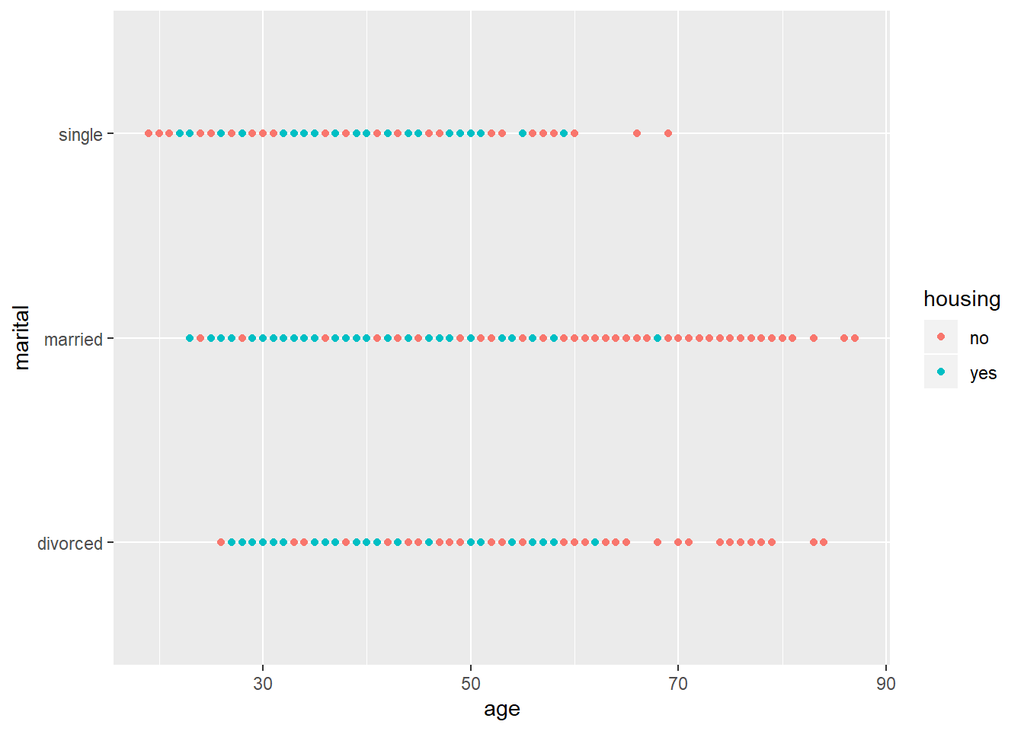

```r
ggplot(bank, aes(age, marital, color = housing)) + geom_point()
```

# Finding #2

If aged (age>60) customers are less likely to have a house, are they more likely to be rich(a balance higher than 15000)? or rather have a loan?

From the graph, we can see aged customers (age>60) are less likely to be rich, but also less likely to have a loan. This can be interpreted using marital status and housing status.

1. From Finding #1, we know aged customers are less likely to have a house, so they are less likely to have a loan for housing. Meanwhile, older people are more conservative, and are less likely to apply for a loan for daily spends. Thus, it is understandable that aged customers are less likely to have a loan.
2. For Single and Divorced aged customers, they do not have an incentive to leave a legacy to children, so they are more likely to spend more, and thus have lower bank balances
3. For Married aged customers, they may have give their money to children to buy houses (a common practice in China - POOR PARENTS), and thus have lower bank balances.

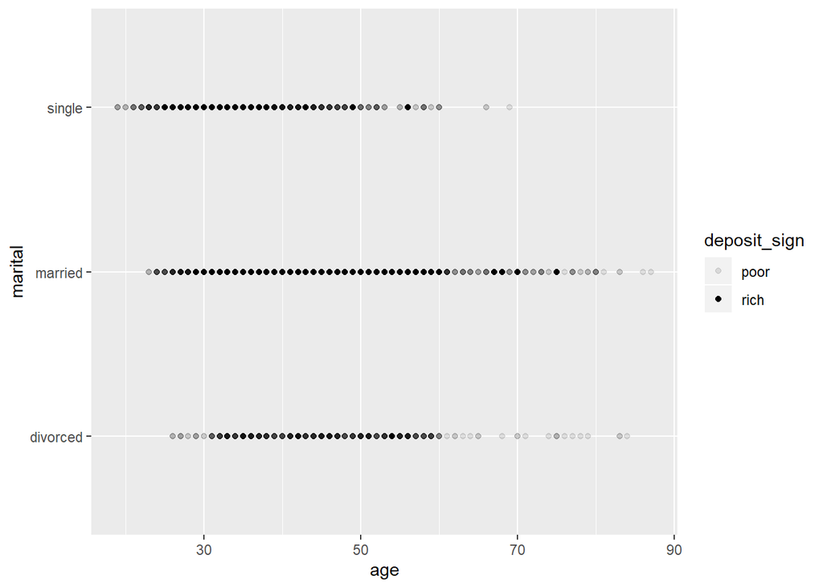

```r
# we use balance > 15000 to indicate rich
bank <- mutate(bank, deposit_sign = ifelse(balance > 15000,"rich","poor"))
ggplot(bank, aes(age, marital, alpha = deposit_sign)) + geom_point()
```

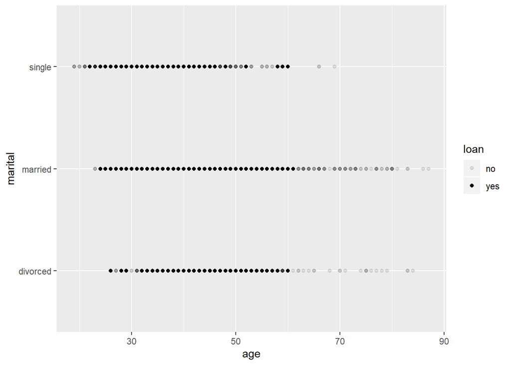

```r
ggplot(bank, aes(age, marital, alpha = loan)) + geom_point()
```

# Finding #3

Poor aged people, no matter the marital status, they are less likely to have a house, less likely to be rich, but luckily less likely to have a loan.

Then, how’s their daily life? My assumption is, if someone is living a good life, they won’t have too much time to spend on the line with the bank.

From the graph, we can see aged customers (age>60) on average spend a higher time(duration) on the line with the bank. So they are not living a good life. This finding is consistent with Finding 1 and Finding 2.

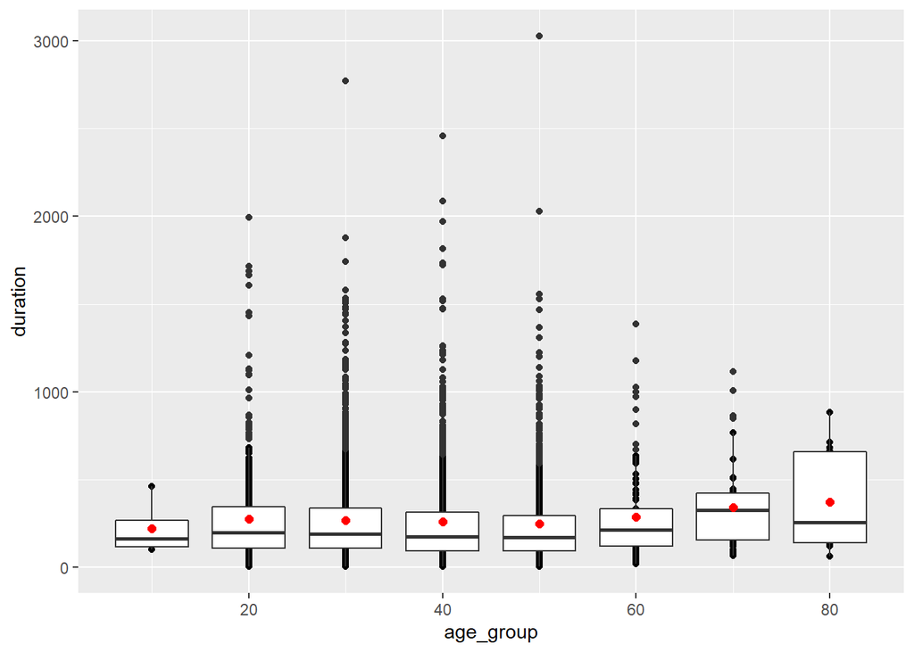

```r
bank <- mutate(bank, age_group = (age %/% 10) * 10)
ggplot(bank, aes(age_group, duration, group = age_group)) + geom_point() + geom_boxplot() +
  stat_summary(fun.y = mean,geom = "point", colour="red", size=2)
```

So SAD! Investigating aged customers (age>60) breaks my heart. I need to move on to something else.

# Finding #4

My parents always tell me, there is gold houses and beautiful girls in books, study hard I can get both(an old chinese saying). But, is it true? Well, the girl part is not contained in the data, the “getting rich” part is investigated. My assumption is a high balance implies being rich.

Intially the first graph was generated, but no conclution could be drawn from it, as it is so badly affected by outliers. So I limited the balance to be less than 20000 and generated the density graph again.

Well, guess what? balance has similar distribution for different education levels, a higher education level not necessarily give you a higher possibility to be rich! (But, the girls part still could be true!)

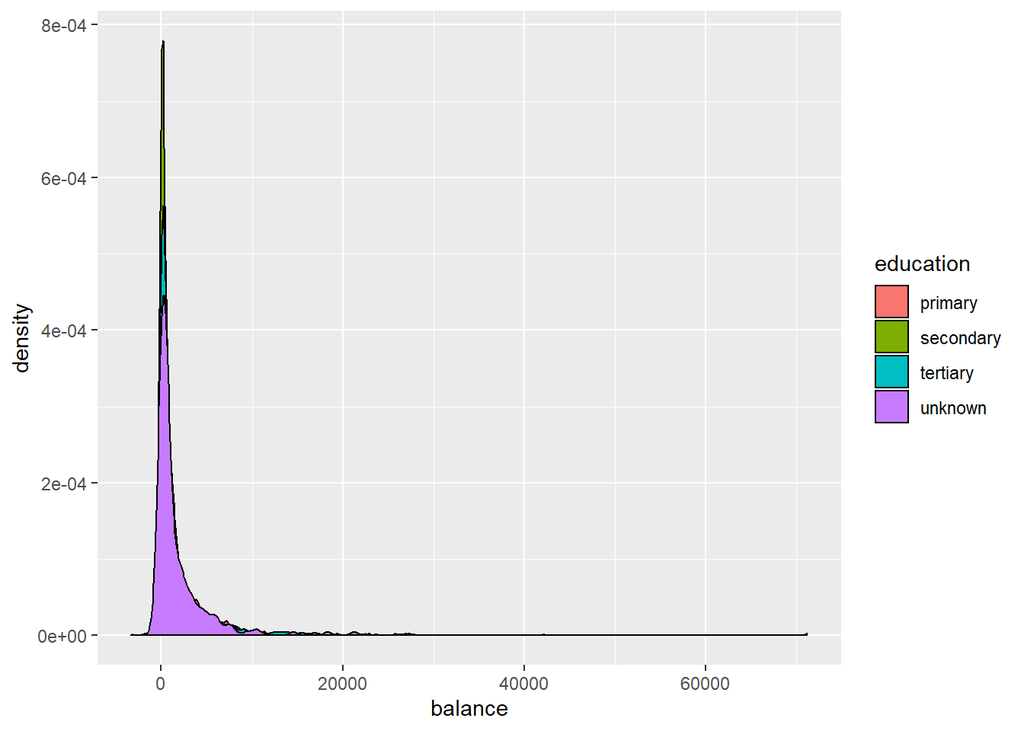

```r
ggplot(bank, aes(balance, fill= education)) + geom_density()
```

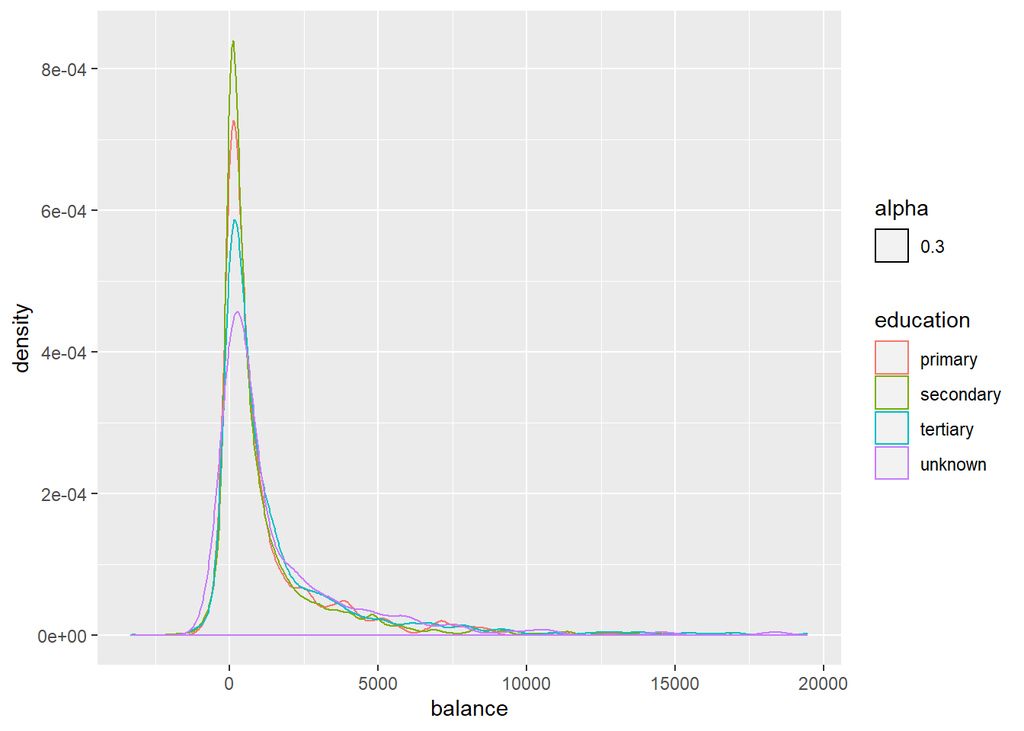

```r
bank_f4 <- dplyr::filter(bank, balance<20000)
ggplot(bank_f4, aes(balance, color = education, alpha = 0.3)) + geom_density()
```

# Finding #5

Education makes people more civilized and have greater sense of responsibility. Does higher education level implies better mirrage? From the graph, no, the probabilities of geting divorced are very similar among all education levels.

And higher education level (tertiary) can even lead to higher possibility of being single…

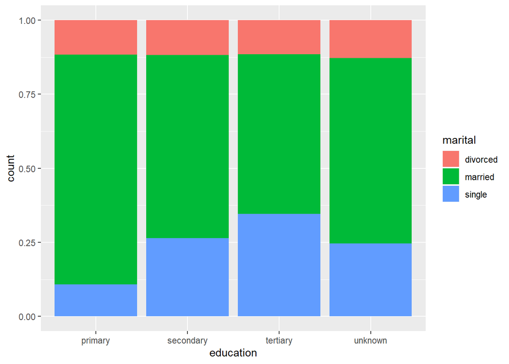

```r
ggplot(bank) + geom_bar(mapping = aes(x=education, fill = marital), position = "fill")
```

# Finding #6

Being well-educated cannot lead to better bank balance or marrige, so I move my focus to choosing a right career path.

I am interested in the roles of “management”, “entrepreneur” and “technician”, so I investigate their balance vs age.

1. For entrepreneur, it’s balance is very volatile and has the possibility of being lower than the population balance.
2. For technician, it’s balance is better than “entrepreneur”, but still has a high chance to be lower than the population balance.
3. For management, it has advantage at all ages except early 20’s, and has a longer career length (until 70)
4. Comparing with the three, management still seems to be the best choice.

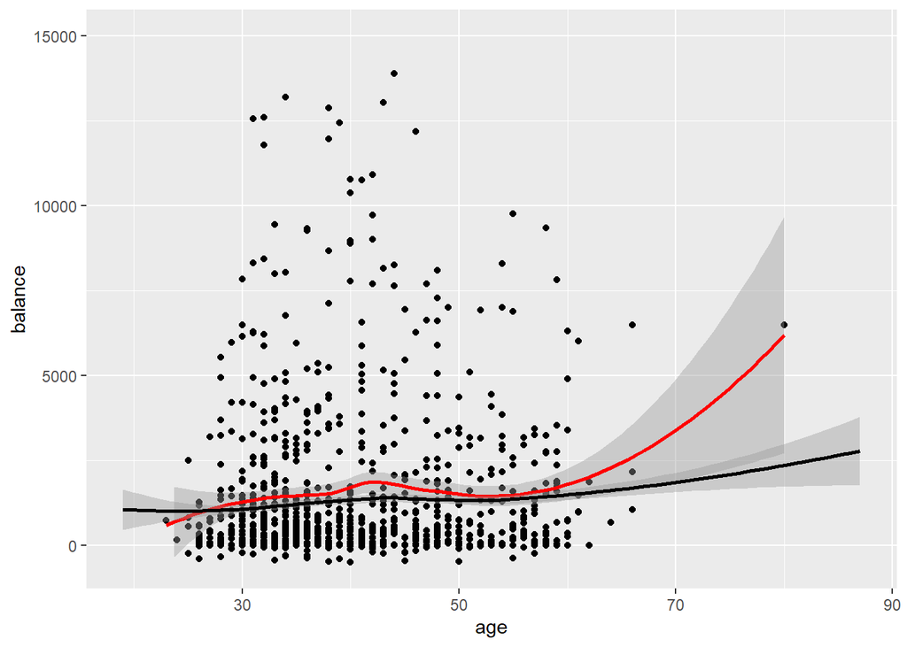

```r
managements <- dplyr::filter(bank, job == "management")
ggplot(managements) +
  geom_point(aes(x = age, y = balance)) +
  geom_smooth(data = managements,
              aes(x = age, y = balance), color = "red", method = "loess") +
  geom_smooth(data = bank,
              aes(x = age, y = balance), color = "black", method = "loess") +
ylim(-500, 15000)
```

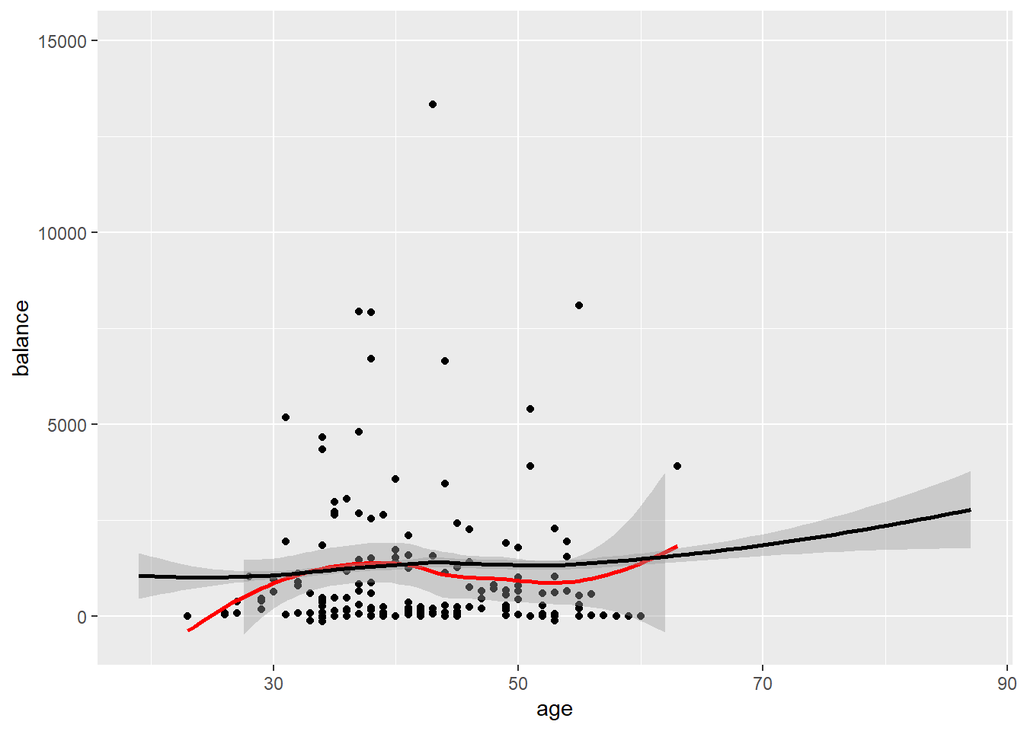

```r
entrepreneurs <- dplyr::filter(bank, job == "entrepreneur")
ggplot(entrepreneurs) +
  geom_point(aes(x = age, y = balance)) +
  geom_smooth(data = entrepreneurs,
              aes(x = age, y = balance), color = "red", method = "loess") +
  geom_smooth(data = bank,
              aes(x = age, y = balance), color = "black", method = "loess") +
ylim(-500, 15000)
```

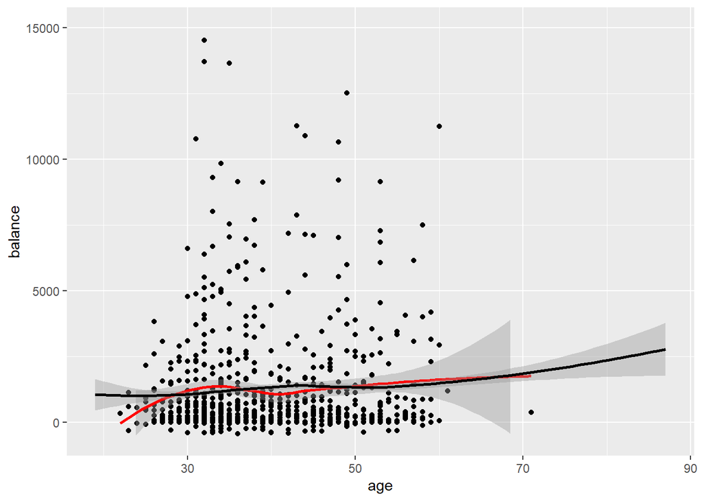

```r
technicians <- dplyr::filter(bank, job == "technician")
ggplot(technicians) +
  geom_point(aes(x = age, y = balance)) +
  geom_smooth(data = technicians,
              aes(x = age, y = balance), color = "red", method = "loess") +
  geom_smooth(data = bank,
              aes(x = age, y = balance), color = "black", method = "loess") +
ylim(-500, 15000)
```

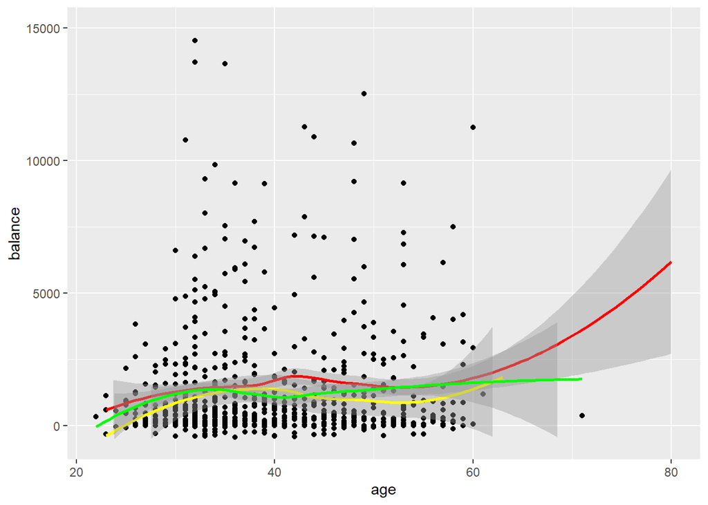

```r
allthree <- bind_rows(managements, entrepreneurs)
allthree <- bind_rows(allthree, technicians)
ggplot(technicians) +
  geom_point(aes(x = age, y = balance)) +
  geom_smooth(data = dplyr::filter(allthree, job == "management"),
              aes(x = age, y = balance), color = "red", method = "loess") +
  geom_smooth(data = dplyr::filter(allthree, job == "entrepreneur"),
              aes(x = age, y = balance), color = "yellow", method = "loess") +
  geom_smooth(data = dplyr::filter(allthree, job == "technician"),
              aes(x = age, y = balance), color = "green", method = "loess") +
ylim(-500, 15000)
```

# Finding #7

So, what does it take to work in the management? Education? Marriage? or Contact(cellular means more travels)?

1. Apparently, being a management requires better education. Management has the highest percentage of “tertiary”.
2. Managment has the highest possibility of getting divorced, and second highest possibility of of being single.
3. Management has the highest percentage of using cellular, so they do travel more.

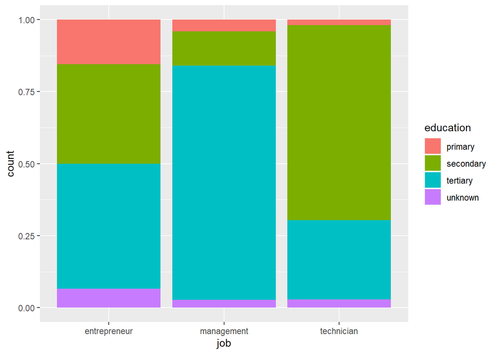

```r
ggplot(allthree) + geom_bar(mapping = aes(x=job, fill = education), position = "fill")
```

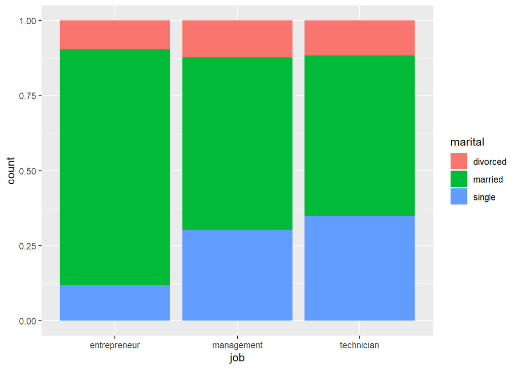

```r
ggplot(allthree) + geom_bar(mapping = aes(x=job, fill = marital), position = "fill")
```

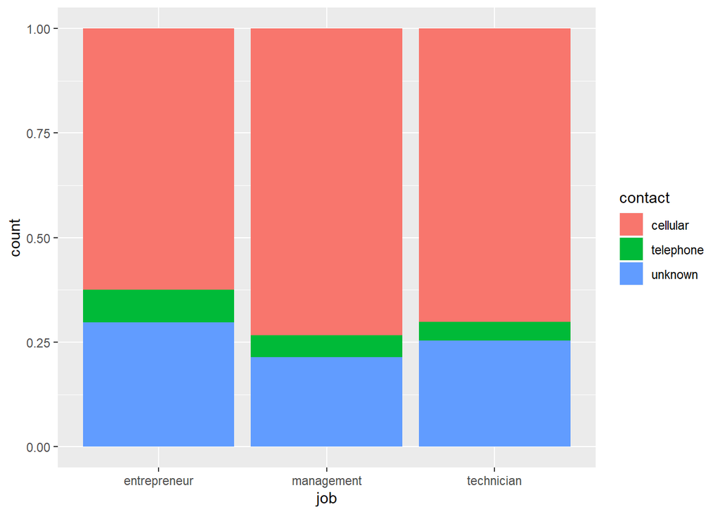

```r
ggplot(allthree) + geom_bar(mapping = aes(x=job, fill = contact), position = "fill")
```

I guess I will continue studying hard!

# Finding #8

1. No matter with a house or not, divorced customers tend to have a low balance. This is consistent with Finding #9 in Assignment 3.
2. Married customers with no housing tend to have higher balance than those who have housing - very intuitive, especially when housing price is this high!
3. Single customers have similar balance no matter with or without housing.

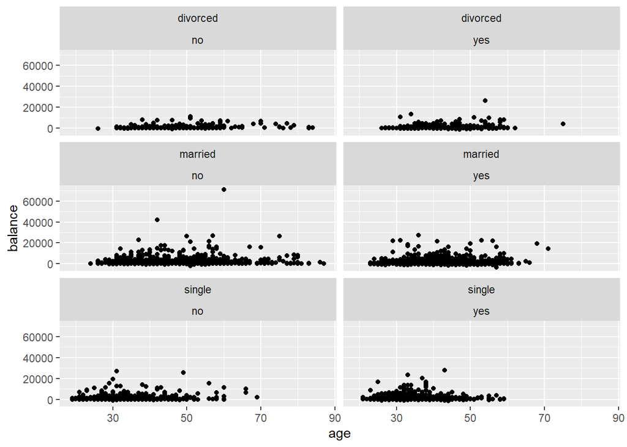

```r
ggplot(data = bank) +
    geom_point(mapping = aes(x = age, y = balance)) +
    facet_wrap(marital ~ housing, nrow = 3)
```

# Finding #9

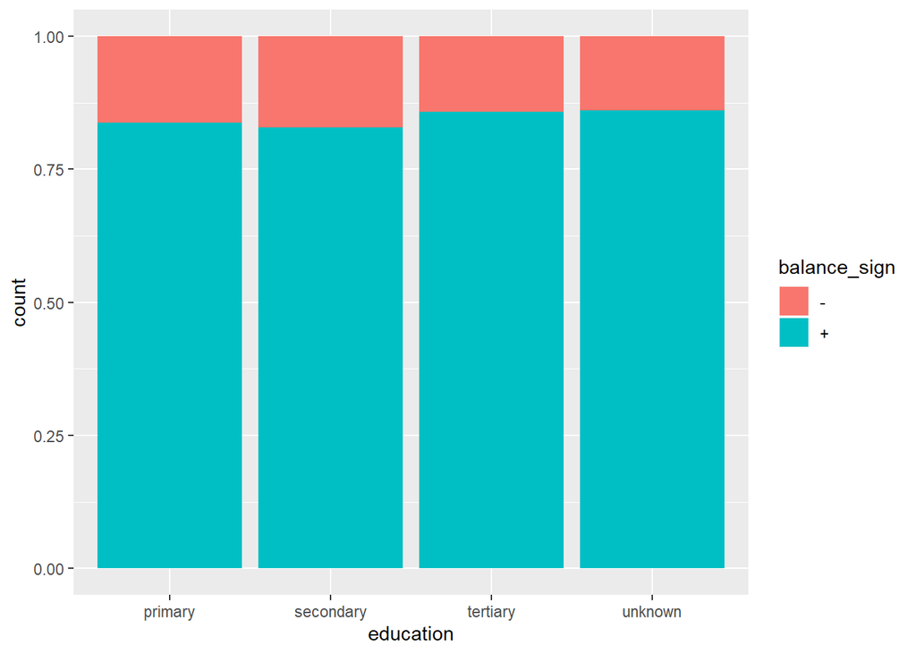

```r
bank <- mutate(bank, balance_sign = ifelse(balance > 0, "+", "-"))
allthree <- mutate(allthree, balance_sign = ifelse(balance > 0, "+", "-"))
ggplot(bank) + geom_bar(aes(x = education, fill = balance_sign), position = "fill")
```

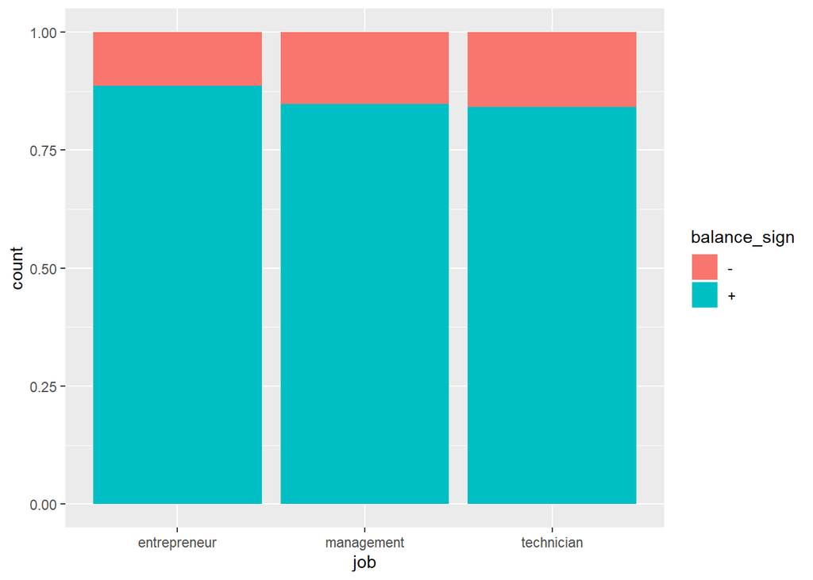

```r
ggplot(allthree) + geom_bar(aes(x = job, fill = balance_sign), position = "fill")
```

# Finding #10

Two simple observation to wrap up this long and in-depth analyis.

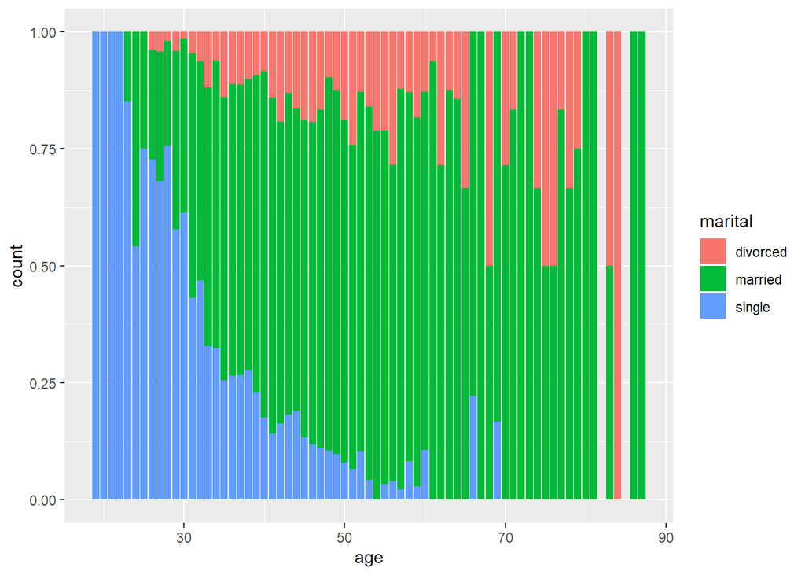

```r
ggplot(bank) + geom_bar(mapping = aes(x=age, fill = marital), position = "fill")
```

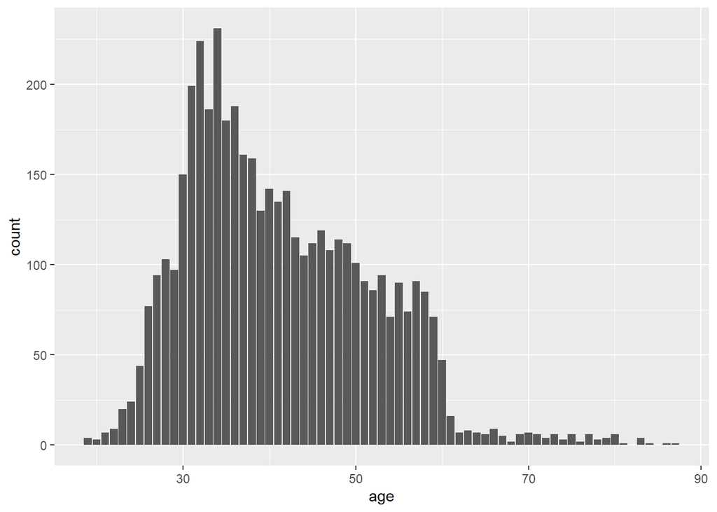

```r
ggplot(bank) + geom_bar(mapping = aes(x=age))
```